# data wrangling assignment

Nikhil Chepena, Rohin Sri Kumar

10/04/2022

Loading the required packages

```r
knitr::opts_chunk$set(echo = FALSE)
library(dplyr)
```

```r
library(tidytext)
library(readr)
library(ggplot2)
library(rvest)
library(tm)
library(wordcloud)
library(syuzhet)
library(wordcloud2)
library(corrplot)
library(textdata)
library(stringr)
library(SnowballC)
```

We are retrieving required data from the wikipidea and displaying the top of the retrieved data

```
## [1] "\n\n\n"
## [2] "Squid Game (Korean: 오징어 게임; RR: Ojing-eo Geim) is a South Korean survival drama television series created by Hwang Dong-hyuk for Netflix. Its cast includes Lee Jung-jae, Park Hae-soo, Wi Ha-joon, HoYeon Jung, O Yeong-su, Heo Sung-tae, Anupam Tripathi, and Kim Joo-ryoung.\n"
## [3] "The series revolves around a contest where 456 players, all of whom are in deep financial debt, risk their lives to play a series of deadly children's games for the chance to win a ₩45.6 billion (US$38 million, €33 million, or GB£29 million as of broadcast) prize. The title of the series dra…
## [4] "Squid Game was released worldwide on September 17, 2021, to critical acclaim and international attention. It is Netflix's most-watched series, becoming the top-viewed program in 94 countries and attracting more than 142 million member households and amassing 1.65 billion viewing hours during…
## [5] "Seong Gi-hun, a divorced father and indebted gambler who lives with his elderly mother, is invited to play a series of children's games for a chance at a large cash prize. Accepting the offer, he is taken to an unknown location where he finds himself among 455 other players who are all deepl…
## [6] "Numbers in parentheses denote the character's assigned number in the Squid Game.\n"
```

First we have replaced some of the special character in the above data. Then we created a corpus, corpus is helpful to apply textmining packages. With the help of tm_map() function we have cleaned the obtained data by first converting the text to lowercase and removing numerical words, punctuations, stopwords, whitespcaes. we also printed the data at every step for verifying whether the data is clean or not. Lastly we also reduced the words to root form by stemming the text. This was done by using the snowballC package.

```
## <<SimpleCorpus>>
## Metadata:  corpus specific: 1, document level (indexed): 0
## Content:  documents: 3
##
## [1] \n\n\n
## [2] squid game (korean: 오징어 게임; rr: ojing-eo geim) is a south korean survival drama television series created by hwang dong-hyuk for netflix. its cast includes lee jung-jae, park hae-soo, wi ha-joon, hoyeon jung, o yeong-su, heo sung-tae, anupam tripathi, and kim joo-ryoung.\n
## [3] the series revolves around a contest where 456 players, all of whom are in deep financial debt, risk their lives to play a series of deadly children's games for the chance to win a ₩45.6 billion (us 38 million,  33 million, or gb 29 million as of broadcast) prize. the title of the series draw…
```

```
## <<SimpleCorpus>>
## Metadata:  corpus specific: 1, document level (indexed): 0
## Content:  documents: 3
##
## [1] \n\n\n
## [2] squid game (korean: 오징어 게임; rr: ojing-eo geim) is a south korean survival drama television series created by hwang dong-hyuk for netflix. its cast includes lee jung-jae, park hae-soo, wi ha-joon, hoyeon jung, o yeong-su, heo sung-tae, anupam tripathi, and kim joo-ryoung.\n
## [3] the series revolves around a contest where  players, all of whom are in deep financial debt, risk their lives to play a series of deadly children's games for the chance to win a ₩. billion (us  million,   million, or gb  million as of broadcast) prize. the title of the series draws from a sim…
```

```
## <<SimpleCorpus>>
## Metadata:  corpus specific: 1, document level (indexed): 0
## Content:  documents: 3
##
## [1] \n\n\n
## [2] squid game (korean: 오징어 게임; rr: ojing-eo geim)   south korean survival drama television series created  hwang dong-hyuk  netflix.  cast includes lee jung-jae, park hae-soo, wi ha-joon, hoyeon jung, o yeong-su, heo sung-tae, anupam tripathi,  kim joo-ryoung.\n
## [3]  series revolves around  contest   players,      deep financial debt, risk  lives  play  series  deadly children's games   chance  win  ₩. billion (us  million,   million,  gb  million   broadcast) prize.  title   series draws   similarly named korean children's game. hwang  conceived   idea …
```

```
## <<SimpleCorpus>>
## Metadata:  corpus specific: 1, document level (indexed): 0
## Content:  documents: 3
##
## [1] \n\n\n
## [2] squid game korean 오징어 게임 rr ojingeo geim   south korean survival drama television series created  hwang donghyuk  netflix  cast includes lee jungjae park haesoo wi hajoon hoyeon jung o yeongsu heo sungtae anupam tripathi  kim jooryoung\n
## [3]  series revolves around  contest   players      deep financial debt risk  lives  play  series  deadly childrens games   chance  win  ₩ billion us  million   million  gb  million   broadcast prize  title   series draws   similarly named korean childrens game hwang  conceived   idea based    ec…
```

```
## <<SimpleCorpus>>
## Metadata:  corpus specific: 1, document level (indexed): 0
## Content:  documents: 3
##
## [1]
## [2] squid game korean 오징어 게임 rr ojingeo geim south korean survival drama television series created hwang donghyuk netflix cast includes lee jungjae park haesoo wi hajoon hoyeon jung o yeongsu heo sungtae anupam tripathi kim jooryoung
## [3]  series revolves around contest players deep financial debt risk lives play series deadly childrens games chance win ₩ billion us million million gb million broadcast prize title series draws similarly named korean childrens game hwang conceived idea based economic struggles early life well c…
```

we then used the term document matrix function to count the number of occurrence of each words. displayed the top 20 frequent words.

```
## # A tibble: 20 × 2
##    word    frequency
##    <chr>       <dbl>
##  1 game          146
##  2 squid          88
##  3 hwang          64
##  4 seri           60
##  5 show           60
##  6 korean         50
##  7 netflix        40
##  8 use            37
##  9 player         28
## 10 also           28
## 11 said           28
## 12 film           24
## 13 work           24
## 14 south          23
## 15 first          23
## 16 peopl          21
## 17 korea          20
## 18 watch          20
## 19 episod         20
## 20 state          20
```

using the ggplot we then try to visually represent the top 10 frequently used words.

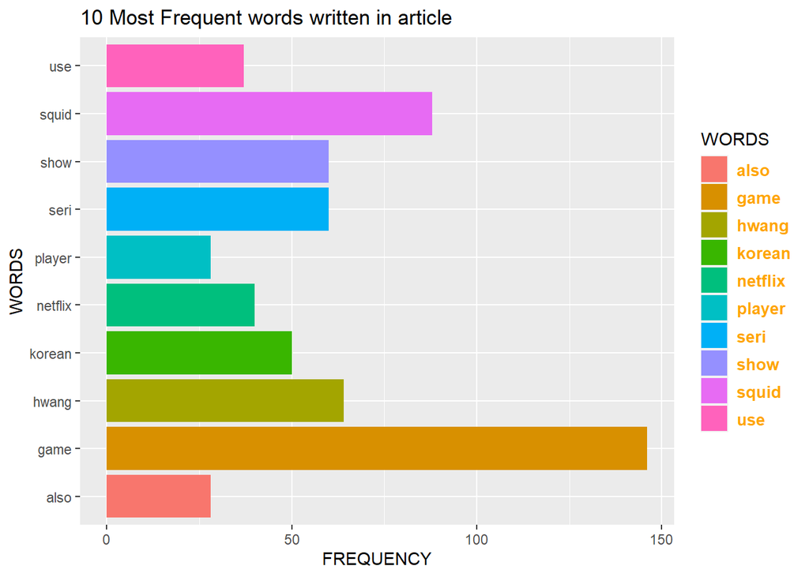

with the wordcloud package we generated a wordcloud plot and also a wordcloud html widget.

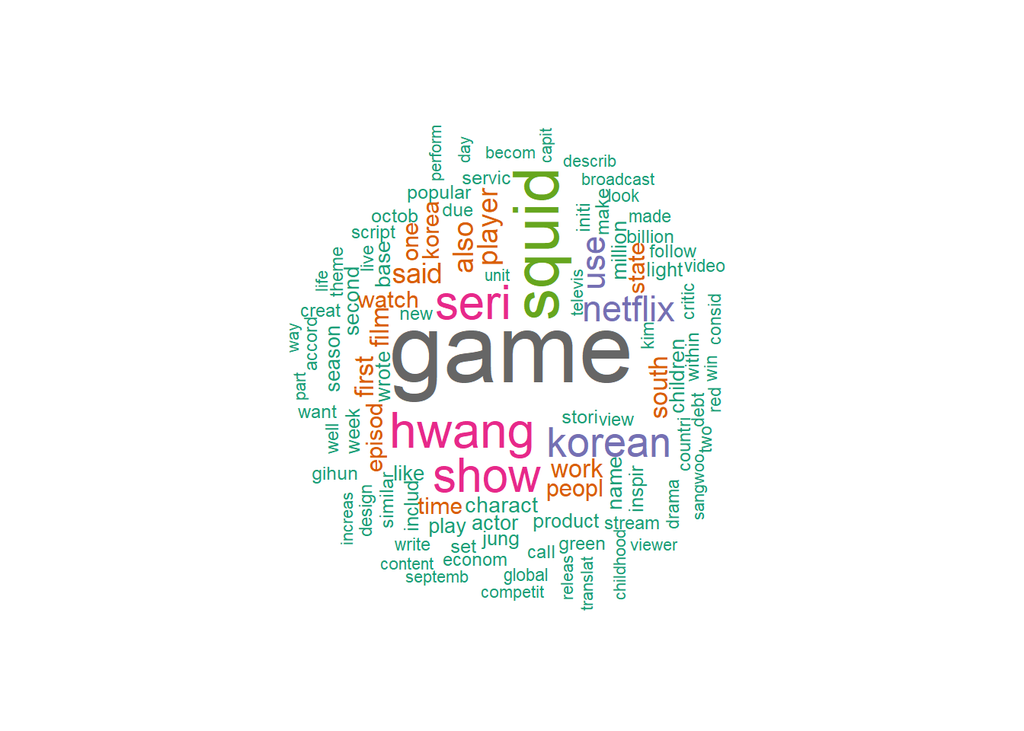

[interactive chart not shown]

to find correlation between the words i.e which words occur most commonly in association with the given word, we used the find association function to accomplish this. we have set the correlation limit to 0.55 we also used the find freq terms function to get all the words that occur atleast 10times

```
##  [1] "creat"    "game"     "hwang"    "includ"   "jung"     "kim"
##  [7] "korean"   "netflix"  "seri"     "south"    "squid"    "base"
## [13] "billion"  "children" "econom"   "initi"    "korea"    "live"
## [19] "million"  "name"     "play"     "player"   "product"  "similar"
## [25] "well"     "actor"    "also"     "countri"  "critic"   "film"
## [31] "first"    "make"     "season"   "second"   "show"     "view"
## [37] "watch"    "week"     "gihun"    "green"    "time"     "charact"
## [43] "episod"   "one"      "like"     "script"   "state"    "stori"
## [49] "use"      "want"     "within"   "work"     "call"     "peopl"
## [55] "said"     "servic"   "accord"   "wrote"    "inspir"   "light"
## [61] "popular"  "new"      "due"      "octob"    "design"   "set"
## [67] "theme"    "follow"   "stream"
```

```
## $game
##             central               squid            children               group
##                0.84                0.69                0.69                0.66
##             kingdom                 red               activ                auto
##                0.63                0.62                0.61                0.61
##                 ban              canada               cooki                crab
##                0.61                0.61                0.61                0.61
##              despit                emul             exposur fayettevillemanlius
##                0.61                0.61                0.61                0.61
##             fortnit               level               matur              parent
##                0.61                0.61                0.61                0.61
##              quebec              recess              roblox                safe
##                0.61                0.61                0.61                0.61
##               short               theft                user              usercr
##                0.61                0.61                0.61                0.61
##                warn               young             aggress               alley
##                0.61                0.61                0.56                0.56
##               bloom               child                danc              ddakji
##                0.56                0.56                0.56                0.56
##                done                dong          dongdaemun                easi
##                0.56                0.56                0.56                0.56
##             explain                fill                 gat              gonggi
##                0.56                0.56                0.56                0.56
##                hana                 hat                hous                ichi
##                0.56                0.56                0.56                0.56
##              import            influenc              intend                joke
##                0.56                0.56                0.56                0.56
##              legend                lick                 lot                monm
##                0.56                0.56                0.56                0.56
##               paper              paperg                pick              random
##                0.56                0.56                0.56                0.56
##               recal             ridicul               simpl               stake
##                0.56                0.56                0.56                0.56
##                stop         survivaltyp              symbol               urban
##                0.56                0.56                0.56                0.56
##             variant                왔니                  왜                우리
##                0.56                0.56                0.56                0.56
##                집에              school
##                0.56                0.56
```

```
## $squid
##     game internet    video   novemb
##     0.69     0.61     0.60     0.58
```

```
## $netflix
##  sarando     knew   return minyoung     oper     look
##     0.68     0.66     0.66     0.58     0.58     0.57
```

We are using syuzhet, bing ,afinn , nrc lexicons for this project. for the syuzhet, bing, afinn we are using the get_sentiment function. These 3 methods have different scales for sentiment analysis.

we have appllied these three methods to the data and also displayed the vectors and summary statistics of each method.

```
## [1]  0.00  0.35 -0.70  7.55  2.10  0.00
```

```
##    Min. 1st Qu.  Median    Mean 3rd Qu.    Max.
## -5.6500 -0.2625  0.8000  1.3195  3.0125  7.9000
```

```
## [1]  0  1 -2  8 -1  0
```

```
##     Min.  1st Qu.   Median     Mean  3rd Qu.     Max.
## -10.0000  -1.0000   0.0000   0.1562   1.2500   8.0000
```

```
## [1]  0  2 -3 22  3  0
```

```
##    Min. 1st Qu.  Median    Mean 3rd Qu.    Max.
## -18.000  -2.250   0.000   1.203   4.000  22.000
```

since these three method uses different scales, we need a common scale to have a better understanding to make assumptions. so we have used the inbuilt r bind function to bind rows of the three vectors and then to get the overall emotional valence we have also did the sum of the vector.

```
##      [,1] [,2] [,3] [,4] [,5] [,6]
## [1,]    0    1   -1    1    1    0
## [2,]    0    1   -1    1   -1    0
## [3,]    0    1   -1    1    1    0
```

```
## [1] 84.45
```

```
## [1] 10
```

```
## [1] 77
```

we tried using nrc sentiment lexicons to get a data frame with rows representing sentences for the data 10 columns consists of the 8 emotions and 2 sentiments.

```
## # A tibble: 64 × 10
##    anger anticipation disgust  fear   joy sadness surprise trust negative
##    <dbl>        <dbl>   <dbl> <dbl> <dbl>   <dbl>    <dbl> <dbl>    <dbl>
##  1     0            0       0     0     0       0        0     0        0
##  2     0            0       0     0     0       0        0     1        0
##  3     2            2       2     2     0       4        1     2        6
##  4     0            3       0     0     2       0        1     6        1
##  5     3            6       1     4     5       5        3     7        8
##  6     0            0       0     0     0       0        0     0        0
##  7     0            1       0     0     0       0        0     1        0
##  8     3            6       2     2     3       3        3     6       11
##  9     1            5       1     3     4       3        1     7        4
## 10     0            3       0     0     2       0        1     7        3
## # … with 54 more rows, and 1 more variable: positive <dbl>
```

We have then created a tibble with the total count associated with each emotion.

```
## # A tibble: 10 × 2
##    sentiment    count
##    <chr>        <dbl>
##  1 anger           38
##  2 anticipation   102
##  3 disgust         20
##  4 fear            60
##  5 joy             94
##  6 sadness         51
##  7 surprise        56
##  8 trust          146
##  9 negative       111
## 10 positive       233
```

we then created a bar plot with all the emotions using ggplot.

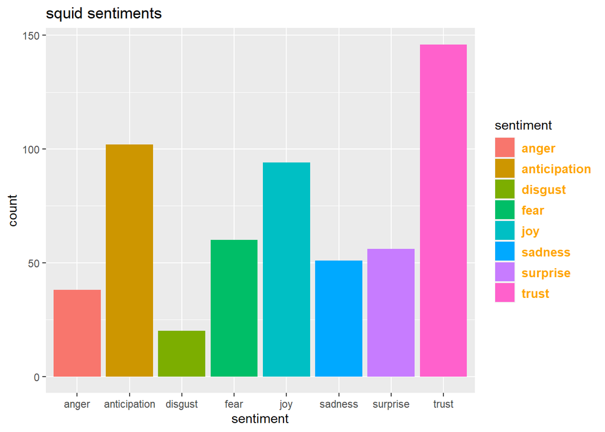

Inorder to get a better understanding we have created a barplot with percentage of each emotion. This helps in understanding the the percentage of words which are associated with each emotion.

[figure not shown]